# Impacts of DNA extraction and PCR on DNA metabarcoding estimates of soil biodiversity - Dopheide - 2019 - Methods in Ecology and Evolution - Wiley Online Library

[Methods in Ecology and Evolution](https://besjournals.onlinelibrary.wiley.com/journal/2041210x)

[Volume 10, Issue 1](https://besjournals.onlinelibrary.wiley.com/toc/2041210x/2019/10/1) p. 120-133

RESEARCH ARTICLE

Free Access

# Impacts of DNA extraction and PCR on DNA metabarcoding estimates of soil biodiversity

[Andrew Dopheide](https://besjournals.onlinelibrary.wiley.com/authored-by/ContribAuthorRaw/Dopheide/Andrew),

[Dong Xie](https://besjournals.onlinelibrary.wiley.com/authored-by/ContribAuthorRaw/Xie/Dong),

[Thomas R. Buckley](https://besjournals.onlinelibrary.wiley.com/authored-by/ContribAuthorRaw/Buckley/Thomas+R.),

[Alexei J. Drummond](https://besjournals.onlinelibrary.wiley.com/authored-by/ContribAuthorRaw/Drummond/Alexei+J.),

[Richard D. Newcomb](https://besjournals.onlinelibrary.wiley.com/authored-by/ContribAuthorRaw/Newcomb/Richard+D.),

First published: 03 September 2018

https://doi.org/10.1111/2041-210X.13086

Citations: 35

## Abstract

1. Soils are ubiquitous and important components of terrestrial ecosystems, richly populated with diverse organisms with important ecological roles. DNA metabarcoding is a promising tool for efficient and taxonomically comprehensive analyses of soil biodiversity, but the outcomes of these analyses are likely affected by basic methodological factors such as sampling and laboratory protocols.
2. We investigated the impacts of DNA extraction methodology and multiple PCRs on DNA metabarcoding biodiversity estimates for multiple taxonomic groups in soil. We applied four DNA extraction methods with different size constraints in parallel to fixed volumes of soil from a pair of forest sites, followed by sets of ten individually indexed PCRs and Illumina sequencing of prokaryote (16S) and eukaryote (18S, fungal 26S, and metazoan cytochrome *c* oxidase subunit I) barcodes.
3. Methods utilizing larger soil volumes resulted in higher biodiversity estimates for arthropods but not for prokaryotes or microeukaryotes, and improved spatial discrimination of metazoan communities but not prokaryotes. Each DNA extraction method resulted in a biased community composition, and these biases were consistent across sites and amplicons. Some 36%–41% of operational taxonomic units (OTUs) were shared between all four DNA extraction methods and OTUs from many phyla had contrasting abundances from different methods. From 0.2% to 19% of OTUs, accounting for 9.4% to 97% of sequence reads, were amplified in all 10 PCRs from each DNA extraction method and sample. OTUs detected in only a single PCR accounted for 26% to 41% of OTUs but only 0.3% to 2.8% of the sequence reads from each extraction method and sample. The inferred species richness increased strongly with the number of PCRs carried out.
4. We conclude that a consistent DNA extraction method should be used for comparisons between samples, confirm that larger samples of soil (≥15 g) should be used for analyses of metazoan biodiversity than for microbes, and that the number of PCR replicates undertaken strongly affects species richness estimates.

## 1 INTRODUCTION

DNA metabarcoding techniques have enabled the efficient characterization and monitoring of prokaryote and eukaryote communities in terrestrial ecosystems (e.g., Buée et al., 2009; Caporaso et al., 2011; Drummond et al., 2015; Ji et al., 2013). Soil is a promising substrate for comprehensive DNA metabarcoding analyses of terrestrial biodiversity, due to the great abundance and diversity of organisms and biological debris that are present in soils (Buée et al., 2009; Giller, 1996; Torsvik & Øvreås, 2002). Furthermore, soil communities are key contributors to ecological processes such as decomposition and nutrient cycling, yet knowledge of these communities lags behind that of above-ground biodiversity (Bardgett & Van Der Putten, 2014; Decaëns, 2010).

DNA metabarcoding analyses involve a series of methodological decisions that are likely to affect measures of biodiversity (Alberdi, Aizpurua, Gilbert, & Bohmann, 2017; Dickie et al., 2018; Murray, Coghlan, & Bunce, 2015). The effects of DNA extraction methods on DNA yield and detected microbial community composition have been examined for substrates including oral and rumen samples (Henderson et al., 2013; Vesty, Biswas, Taylor, Gear, & Douglas, 2017), permafrost (Vishnivetskaya et al., 2014), and soils (Delmont et al., 2011; Kang & Mills, 2006; Wagner, Praeg, Reitschuler, & Illmer, 2015). In soils, the detection of prokaryote communities is affected by site-specific factors such as spatial heterogeneity and the propensity of cells and molecules to adsorb to soil particles (Lombard, Prestat, van Elsas, & Simonet, 2011), sample size (Kang & Mills, 2006), and extraction method (Delmont et al., 2011). Eukaryotes, particularly metazoans, are larger and less abundant but more heterogeneous in morphology and size than prokaryotes, suggesting that different sampling and DNA extraction strategies are necessary to characterize the biodiversity of these organisms in soil. Taberlet et al. (2012) proposed a method for recovery of extracellular DNA from large volumes of soil in order to reduce sample heterogeneity, resulting in lower DNA yield and quality but congruent community composition compared to a conventional DNA extraction kit (Zinger et al., 2016). Otherwise, the impacts of DNA extraction method on biodiversity estimates for eukaryote groups in soil have rarely been assessed.

Polymerase chain reaction amplification is susceptible to various biases, artefacts, and errors (Acinas, Sarma-Rupavtarm, Klepac-Ceraj, & Polz, 2005; Elbrecht & Leese, 2015; Murray et al., 2015; Polz & Cavanaugh, 1998), the occurrences of which are influenced by factors including the DNA template diversity (Fonseca, Nichols, & Lallias, 2012), and thermal cycling parameters (Qiu et al., 2001; Stevens, Jackson, & Olson, 2013). Stochastic PCR variability may also affect the outcomes of metabarcoding-based biodiversity analyses (Leray & Knowlton, 2017; Tedersoo et al., 2010; Zhou et al., 2011), particularly for low-abundance template molecules. Replication of PCRs is widely included in metabarcoding analyses to counter such variability, but the number of replicates that are included is usually arbitrary. Ficetola et al. (2015) and Piggott (2016) investigated how many replicates were required to confidently detect a target species, which ranged from two to six (Piggott, 2016), or eight (Ficetola et al., 2015) depending on the methods used and the detection probability of the target. The effects of PCR replication on multitaxon metabarcoding biodiversity estimates have otherwise received little attention. For example, it is unclear how the number of PCRs undertaken affects estimates of soil biodiversity, and whether this varies among different taxonomic groups.

In this study, we applied four different DNA extraction methods with differing size limits in parallel to fixed volumes of soil collected from a pair of spatially separated forest sites, followed by Illumina sequencing of sets of 10 individually indexed PCRs for prokaryote 16S, eukaryote 18S, fungal 26S, and metazoan cytochrome *c* oxidase subunit I (COI) barcode genes. We investigated whether the DNA extraction method affects the range of organisms detected or biodiversity estimates for prokaryotes and eukaryote groups, and whether spatially separated soil communities can be discriminated based on the results of different extraction methods and taxa. In addition, we examined the variability in PCR amplifications and how the number of PCRs undertaken affects estimates of prokaryote and eukaryote soil biodiversity.

## 2 MATERIALS AND METHODS

### Sample collection

Soil samples were collected in the forested Waitakere Ranges Regional Park, located west of Auckland in the North Island of New Zealand (latitude −36.906, longitude 174.520). The sample site is a 20 × 20 m grid of 16 subplots (each 5 × 5 m), identified by letters A through P. Approximately 2.0 kg of soil was collected from each of two diagonally opposite corner subplots (D and P, approximately 21 m apart; Figure S1), by excavating soil and overlying leaf litter at semirandom locations to a depth of 10 cm. The soil material was sealed in plastic bags and stored at −80°C until DNA extraction was undertaken.

### DNA extraction, PCR, and sequencing

Each soil sample was homogenized before removal of four 15-g subsamples, for DNA extractions using four different methods followed by a fixed number of PCRs (Figure S1). The extraction methods included two widely used soil DNA extraction kits with contrasting upper size limits, and two methods that can be applied to samples of arbitrary size that were expected to be more effective for metazoan biodiversity analyses.

In the first DNA extraction method (1.5 g direct), DNA was extracted from ten 1.5-g soil aliquots using the MoBio Powersoil RNA extraction kit with DNA elution accessory kit (MoBio Laboratories, Carlsbad, CA). These DNA extracts were further processed through a Nucleospin Soil extraction kit (Macherey-Nagel GMBH & CO. KG, Dueren, Germany), omitting lysis steps, to remove apparent PCR inhibitors. In the second method (7.5 g direct), DNA was extracted from two 7.5-g soil aliquots using the MoBio Powermax DNA extraction kit (MoBio Laboratories). In the third method (indirect extraction), biological material was separated from 15 g of soil using a modified sugar centrifugation protocol (Freckman & Virginia, 1993; Velasco-Castrillón et al., 2014), before DNA extraction from the separated material using a Nucleospin Soil DNA extraction kit (Macherey-Nagel GMBH & CO. KG). In the fourth method (phosphate buffer extraction), 15 g of soil was mixed with saturated phosphate buffer (0.12 M¸ pH 8) for 20 min before DNA extraction from a 100-μl aliquot of buffer liquid using a Nucleospin Soil DNA extraction kit (Macherey-Nagel GMBH & CO. KG), excluding the lysis steps (Taberlet et al., 2012).

Four barcode regions covering the major taxonomic groups found in soil were amplified by PCR from each extract: an average 570 b.p. (*SD* = 7) of the prokaryote 16S V4–V6 region using primers 530F and 1100R (Acosta-Martínez, Dowd, Sun, & Allen, 2008); 338 b.p. (*SD* = 37) of the eukaryote 18S V7–V8 region using primers #3-F and #5-RC (Machida & Knowlton, 2012); 578 b.p. (*SD* = 37) of the fungal 26S D1–D2 region using primers NL1 and NL4 (Kurtzman & Robnett, 1998); and a 313 b.p. fragment of the metazoan COI gene, using primers mICOIintF and jgHCO2198 (Leray et al., 2013) (Table S1). One PCR was carried out for each of the ten 1.5-g direct extracts, five PCRs were carried out on each of the two 7.5-g direct extracts, and 10 PCRs were carried out for each of the 15 g indirect and 15 g phosphate buffer extracts, giving a total of 10 PCRs per gene from each 15-g soil subsample, for two subplots (80 PCRs in total for each gene). The sets of 10 PCRs from the 15 g indirect and 15 g phosphate buffer extracts are PCR replicates, as are the sets of five PCRs from 7.5 g direct extracts, whereas the PCRs from 1.5 g direct extracts represent replicate subsamples/extractions.

The PCRs were carried out in 25 μl reaction volumes containing 0.5 units of KAPA 2G Robust Hotstart polymerase (Kapa Biosystems Inc, Boston, MA), MgCl<sub>2</sub> at a concentration of 1.5 mmol/L, dNTPs at a concentration of 0.2 mmol/L, forward and reverse primers at a concentration of 0.2 μmol/L each, and 20–25 ng of template DNA. The temperature cycle used for PCRs was (a) 94°C for 3 min; (b) 25 cycles (16S), 27 cycles (18S and 26S), or 30 cycles (COI) of 94°C for 30 s, 60°C (16S), 58°C (18S), 52°C (26S), or 48°C (COI) for 30 s, and 72°C for 45 s; (c) 72°C for 3 min. All PCR mixes were prepared in a dedicated laminar flow hood with a dedicated set of micropipettes. Negative control reactions containing nuclease-free water instead of DNA template were carried out in parallel with all sets of PCRs.

The PCR amplicons were cleaned up using the Ampure XP magnetic bead system (Beckmann-Coulter, MA) and pooled in sets of four (one each of 16S, 18S, 26S, and COI amplicons), resulting in a total of 80 amplicon pools. Dual barcode indices and sequencing adaptors were attached to each amplicon pool using an Illumina Nextera XT Index kit, followed by a further Ampure XP cleanup step, quantification and normalization of DNA concentration, and combining of pools for sequencing. The combined pool was sequenced by New Zealand Genomics Ltd. in a 2 × 300 b.p. Illumina MiSeq run.

### Sequence processing and bioinformatics

Paired sequence reads for each amplicon pool were merged using PEAR paired-end read merger version 0.9.3 (Zhang, Kobert, Flouri, & Stamatakis, 2014), then separated by primer, trimmed of primers, and relabelled by amplicon pool using custom python scripts. Few of the paired reads from the prokaryote 16S and fungal 26S amplicons successfully merged, as the length of these amplicons (including primers) tended to exceed the maximum read length of the MiSeq system, and therefore only the (higher quality) R1 sequences from these amplicons were used in analyses.

The merged sequences (18S and COI) were not length trimmed, whereas the 16S and 26S R1 sequences were uniformly trimmed to 250 b.p. to remove the lowest quality 3ʹ regions, followed by quality filtering, initially at different stringency levels (removal of sequences with >2.5, >1.0, or >0.5 maximum expected errors) to examine the effects of this factor on alpha diversity estimates (Table S2). For subsequent analyses, any sequences with maximum expected errors >1.0 were removed. Any duplicates among the quality-filtered sequences were removed, followed by clustering of the nonduplicates into operational taxonomic units (OTUs) at a 97% identity threshold (with singleton sequences either included or excluded), with simultaneous chimera filtering, after which the quality-filtered sequences were matched to the OTUs at a 97% identity threshold, using UPARSE and other functions within usearch v8.0.1623 (Edgar, 2013). The taxonomic identity of OTUs was determined using BLAST to compare sequences with the NCBI Genbank nr nucleotide database. BLAST results were parsed using the lowest-common-ancestor algorithm in MEGAN metagenome analyser (Huson, Mitra, Ruscheweyh, Weber, & Schuster, 2011), resulting in a consensus taxonomic assignment for each OTU.

### Biodiversity analyses

To compare the biodiversity detected among different samples and DNA extraction methods based on different taxa, the pool of sequences per PCR was randomly subsampled to the lowest number of sequence reads per PCR within the results from each amplicon (after exclusion of any PCRs with <25% of the mean sequence abundance per PCR), after which richness and effective diversity metrics (Jost, 2006) were calculated for taxonomic groups based on the subsampled PCRs from each sample and extraction method using the r package vegetarian (Charney & Record, 2012). The subsampling and diversity calculations were repeated 10 times for each amplicon.

The overlap between DNA extraction methods was investigated by determining the proportions of OTUs with minimum abundances of 1–10 sequence reads that were detected in the results of multiple extraction methods. To identify OTUs with differing abundances between samples and DNA extraction methods, OTU abundances were normalized according to a negative binomial model, as recommended by McMurdie and Holmes (2014) using the r packages DESeq2 (Love, Huber, & Anders, 2014) and phyloseq (McMurdie & Holmes, 2013). Log twofold differences in normalized OTU abundances between samples and extraction methods were identified by negative binomial Wald tests in DESeq2, with correction for multiple inferences using the Benjamini–Hochberg method for control of the False Discovery Rate (Benjamini & Hochberg, 1995). Nonmetric multidimensional scaling (MDS) ordinations and other multivariate comparisons of community composition between samples, extraction methods, PCRs, and taxonomic groups were carried out using the r package vegan (Oksanen et al., 2017).

To analyse the effects of multiple PCRs on biodiversity estimates, 25 random combinations of results from 1–10 PCRs were selected for each amplicon and extraction method, followed by calculation of diversity estimates from each combination of PCRs, both with and without subsampling to an equal number of sequence reads for every amplicon and extraction method. To investigate whether exclusion of low-abundance OTUs affected these results, these calculations were repeated with OTUs with total abundances <5 excluded, and with OTUs occurring in <2 of each set of ten PCRs excluded. In addition, to investigate the effect of sequencing depth on biodiversity estimates, the total sequence pool from each amplicon and method was randomly subsampled to ten-percentile intervals from 10% to 100%, followed by calculation of diversity estimates. All biodiversity analyses were based on OTU clustering with singleton sequences excluded, unless noted otherwise. Figures were generated using ggplot2 (Wickham, 2009). All analyses were carried out in RStudio (RStudio team, 2015) with r version 3.1.1 (R Core Team, 2016).

## 3 RESULTS

### Overall sequencing results

We obtained a total of 9.8 million R1 and 8.8 million R2 sequence reads, with 1.3 million (26S) to 3.5 million (18S) sequences per amplicon (Table S2). The 16S dataset was dominated by bacteria, including 16 bacterial phyla, with Proteobacteria most abundant followed by Actinobacteria, Acidobacteria, and Bacteroidetes (Table S3 and Figure S2). The 18S dataset contained the broadest range of eukaryote taxa, including 6 metazoan phyla, 6 fungal phyla, and 12 protist groups. The 26S dataset included a similar range of fungal and metazoan phyla but fewer protist groups than the 18S dataset. The COI dataset included OTUs from 11 metazoan phyla, 2 fungal phyla, and 9 protist groups.

### Biodiversity differences between DNA extraction methods

We observed differences in biodiversity estimates for eukaryote taxa detected by different extraction methods, related to organism size (Figures 1, S3–S6). In the 18S dataset, the mean species richness and effective alpha diversity estimates for single-celled eukaryote groups such as Amoebozoa, Cercozoa, and (to a lesser extent) Ciliophora were highest in the results of the smallest extractions (1.5 g direct), and effective gamma diversity estimates for these groups were highest in the results of ten 1.5 g direct extractions (Figure 1). For example, Cercozoan species richness in 1.5 g direct extract results was 73 and 81 per subplot, compared to 49–58 for the other methods.

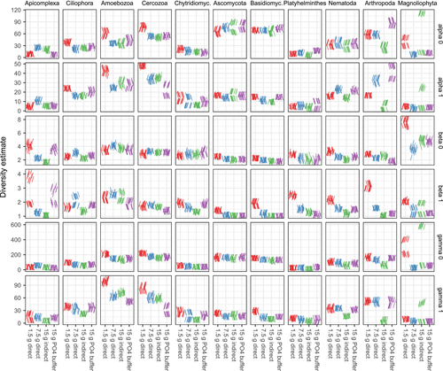

**Figure 1**

Open in figure viewer[PowerPoint](https://besjournals.onlinelibrary.wiley.com/action/downloadFigures?id=mee313086-fig-0001&doi=10.1111%2F2041-210X.13086)

Alpha, beta, and gamma 0 (richness) and 1 (effective diversity, calculated as the exponential of Shannon entropy; Jost, 2006) estimates for 18S phyla detected in the results of four DNA extraction methods and sets of ten PCRs applied to 15 g soil subsamples from two subplots. Each data point represents the estimated mean diversity across 10 PCRs, based on data randomly subsampled to equal read depths for each sample, method, and PCR. The subsampling and diversity estimates were repeated ten times. Forward (/) and back (\) slashes represent separate estimates for samples from subplots D and P respectively. Only phyla with mean estimated species richness ≥8 are shown. Chytridiomyc. and Basidiomyc. denote Chytridiomycota and Basidiomycota respectively

In contrast, mean species richness and effective alpha diversity estimates for 18S Arthropoda OTUs were highest in the results of 15 g phosphate buffer extractions (e.g., richness of 80 and 94 per subplot compared to 18–64 for the other methods). Similarly, alpha diversity estimates for 18S Nematoda OTUs were highest in the results of 15 g phosphate buffer and 7.5 g direct extractions. The estimated gamma diversity of 18S Arthropoda OTUs from 15 g phosphate buffer extractions was similar to estimates from ten 1.5 g direct extractions or two 7.5 g direct extractions, and lowest from 15 g indirect extractions. Effective beta diversity estimates were highest in the results of 1.5 g direct extractions for 18S Arthropoda, Nematoda, and Platyhelminthes OTUs (as well as Basidiomycota), but more consistent among the results of different extraction methods for microeukaryote groups. Similar patterns were observed for Arthropoda biodiversity estimates from the COI dataset (Figure S6).

Alpha diversity estimates for 16S bacterial phyla differed little among the different extraction methods, except for Proteobacteria, for which the highest mean effective alpha diversity was detected from 1.5 g direct extractions (81 and 95 per subplot) and the lowest from phosphate buffer extractions (16 and 27 per subplot) (Figure S3). Alpha and gamma diversity estimates for 26S Ascomycota OTUs varied more between subplots than among extraction methods (except for 1.5 direct extractions), whereas alpha diversity of 26S Basidiomycota OTUs was more consistent among samples and methods (Figure S5).

### OTU differences between DNA extraction methods and samples

Based on OTU clustering with singletons excluded, a large minority of OTUs were present in the results of all four DNA extraction methods (41% of 16S, 40% of 18S, 37% of 26S, and 36% of COI OTUs) (Figure 2). From 12% (18S) to 21% (COI) of OTUs were present in the results of only one extraction method, while the remainder of OTUs occurred in intermediate combinations of DNA extraction methods. Further exclusion of low-abundance OTUs resulted in increasing proportions of OTUs being shared by all methods. For example, 42% (COI) to 60% (16S) of OTUs with abundances ≥5 were present in the results of all methods, as were 54% (COI) to 78% (16S) of OTUs with abundances ≥10. In contrast, if singletons were included in OTU clustering, 47% (COI) to 75% (16S) of the resulting OTUs were present in the results of only a single DNA extraction method (Figure S7).

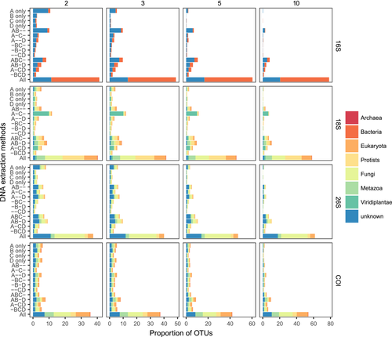

**Figure 2**

Open in figure viewer[PowerPoint](https://besjournals.onlinelibrary.wiley.com/action/downloadFigures?id=mee313086-fig-0002&doi=10.1111%2F2041-210X.13086)

The proportions and taxonomic composition of operational taxonomic units (OTUs) per amplicon with total abundances ≥2, 3, 5, or 10 that were detected in the results of different DNA extraction methods and sets of 10 PCRs applied to 15 g soil subsamples from two subplots. Labels on the y axis indicate the combinations of DNA extraction methods in which OTUs were detected. A: 1.5 g direct extractions; B: 7.5 g direct extractions; C: 15 g indirect extractions; D: 15 g phosphate buffer extractions; All: all four extraction methods

Comparisons of normalized OTU abundances using DESeq2 identified OTUs from a very wide range of taxonomic groups with significantly differing abundances between methods and samples (Table S4 and Figures S8–S11). Overall, in each dataset there were more OTUs with significantly greater abundance in the results of 1.5 g direct extracts compared to the other extraction methods than vice versa (Table S4). For example, in the 18S results, there were 1,027, 1,256, and 1,095 eukaryote OTUs with greater abundance in 1.5 g direct extract results than in 7.5 g direct, 15 g indirect, or 15 g phosphate buffer extract results, respectively, whereas the opposite was true of 370, 507, and 307 eukaryote OTUs respectively. Similar disparities were observed for the other amplicon datasets.

### Variability and spatial discrimination of samples

Nonmetric MDS ordinations indicated that OTU assemblages resulting from PCRs from the same DNA extraction method and sample were in most cases more similar than those resulting from different DNA extraction methods and samples (Figures 3, S12–S15). Sets of replicate PCRs from a single DNA extract were highly consistent. For example, data points representing PCR replicates from each of the 15 g phosphate buffer and indirect extraction methods were in most cases tightly clustered suggesting similar composition. Results from the 7.5 g direct extractions from each sample were usually grouped into two clusters corresponding to sets of five replicate PCRs from each of two extracts, whereas sets of PCRs from individual 1.5 g direct extractions showed the most heterogeneity.

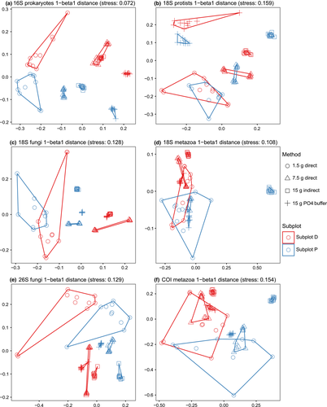

**Figure 3**

Open in figure viewer[PowerPoint](https://besjournals.onlinelibrary.wiley.com/action/downloadFigures?id=mee313086-fig-0003&doi=10.1111%2F2041-210X.13086)

Multivariate community structure (effective beta distance) of (a) 16S prokaryote, (b) 18S protist, (c) 18S fungal, (d) 18S metazoan, (e) 26S fungal, and (f) cytochrome *c* oxidase subunit I (COI) metazoan operational taxonomic unit (OTU) assemblages detected by four DNA extraction methods and sets of 10 PCRs applied to 15 g soil subsamples from two subplots separated by approximately 21 m

Strikingly consistent patterns of community structure related to DNA extraction method were evident between amplicons, taxonomic subsets of each amplicon dataset, and subplots (Figures 3, S12–S15). For example, ordinations based on all 18S, 26S, and COI OTUs were very similar to each other, as were ordinations based on the fungal components of these datasets, with consistent patterns across both subplots. 18S and COI metazoan OTU ordinations also showed very consistent patterns between the two subplots, as did the 16S prokaryote ordination, albeit with a different pattern of similarity among extraction methods compared to the eukaryote datasets (Figure 3). Results from the two different subplots usually formed two nonoverlapping groups regardless of extraction method or taxonomic group, with any overlap generally limited to a subset of the 1.5 g direct extraction results.

Results from 1.5 g direct extractions had the most overlap of within- and between-subplot pairwise distances, for all amplicons and taxonomic groups (Figure 4). The greatest separation of within- and between-subplot pairwise distances was observed for the 15 g indirect or 15 g phosphate buffer extract results, especially for the 18S and COI metazoan OTUs.

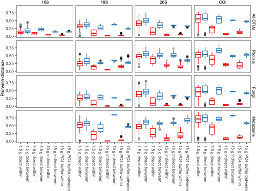

**Figure 4**

Open in figure viewer[PowerPoint](https://besjournals.onlinelibrary.wiley.com/action/downloadFigures?id=mee313086-fig-0004&doi=10.1111%2F2041-210X.13086)

Pairwise multivariate sample similarity (effective beta distance) of operational taxonomic unit (OTU) assemblages and major taxonomic groups detected by four DNA extraction methods and sets of 10 PCRs applied to 15 g soil subsamples from within the same subplot (red) or from different subplots separated by approximately 21 m (blue)

Table 1. PERMANOVA analysis statistics for communities detected by metabarcoding analysis of four amplicons and four DNA extraction methods applied to 15 g soil samples from two subplots separated by approximately 21 m

| Distance metric | Factor | 16S | 18S | 26S | COI |
| --- | --- | --- | --- | --- | --- |
| Effective beta | Subplots | 161.115 (≤0.001) | 64.771 (≤0.001) | 55.958 (≤0.001) | 74.386 (≤0.001) |
|  | Methods | 150.964 (≤0.001) | 41.795 (≤0.001) | 29.908 (≤0.001) | 18.315 (≤0.001) |
|  | Subplots:methods | −6.966 (1) | 9.614 (≤0.001) | 4.197 (≤0.001) | 3.368 (0.003) |
| Jaccard | Subplots | 9.1297 (≤0.001) | 9.58 (≤0.001) | 13.3305 (≤0.001) | 15.5486 (≤0.001) |
|  | Methods | 4.8829 (≤0.001) | 6.1941 (≤0.001) | 5.4355 (≤0.001) | 4.6277 (≤0.001) |
|  | Subplots:methods | 2.3076 (≤0.001) | 2.8773 (≤0.001) | 3.0168 (≤0.001) | 2.8965 (≤0.001) |

### *Notes*

- Values are permutational multivariate analysis of variance (PERMANOVA) *F* statistics with *p*-values in parentheses.
- COI: cytochrome *c* oxidase subunit I.

### Variability in PCRs

Considerable variation in OTU abundance, from one or two to thousands of sequences per OTU, was observed in all amplicon datasets. OTUs that occurred only in the results of a single PCR accounted for 26%–41% (*M* = 31%) of the total OTUs detected in each set of 10 PCRs (Figure 5). However, these OTUs represented only from 0.3% to 2.8% (*M* = 1.2%) of the total sequence reads in each dataset. OTUs that occurred in all 10 PCRs, in contrast, accounted for 0.2%–19% (*M* = 11%) of the total OTUs, but 9.4%–97% (*M* = 77%) of the total sequence reads from each set of ten PCRs. These consistently detected OTUs accounted for the smallest proportions of sequences among sets of ten 1.5 direct extractions and PCRs, particularly for the 26S results (25% and 44% per subplot compared to 83%–92% for the other methods) and COI results (9.4% and 28% per subplot compared to 59%–89% for the other methods). The proportions of OTUs that occurred in at least half of each set of PCRs ranged between 16% and 35% for the 1.5 direct extractions to between 32% and 42% for the 15 g indirect extractions. In most cases, a higher proportion of OTUs occurred in all 10 PCRs than in intermediate numbers (6–9) of PCRs.

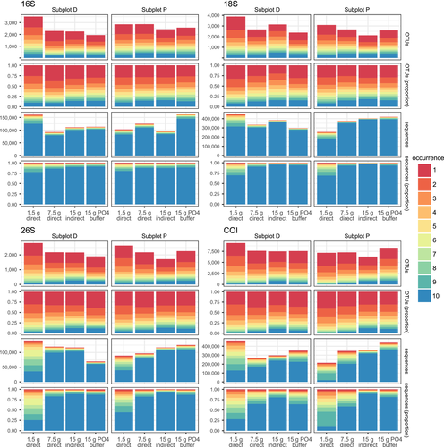

**Figure 5**

Open in figure viewer[PowerPoint](https://besjournals.onlinelibrary.wiley.com/action/downloadFigures?id=mee313086-fig-0005&doi=10.1111%2F2041-210X.13086)

The abundance and occurrence between sets of 10 PCRs for 16S, 18S, 26S, and cytochrome *c* oxidase subunit I (COI) amplicons from four DNA extraction methods applied to 15 g soil subsamples from two subplots. OTUs: operational taxonomic units

Within each set of 10 PCRs from a single DNA extraction method, the 10 most abundant OTUs were usually the same and ranked in the same abundance order in each PCR, even when substantial variation in the total abundance of sequence reads was observed between PCRs (Figures S17–S20). These OTUs were most consistent among replicate PCRs from 15 g indirect and phosphate buffer extractions, and least consistent among sets of PCRs from 1.5 g direct extractions.

### Effects of multiple PCRs on biodiversity estimates

Species richness estimates increased as increasing numbers of PCRs were pooled together (Figures 6, S21). The species richness resulting from 10 pooled PCRs was typically some two- to fourfold higher than the richness resulting from individual PCRs. Species accumulation curves flattened as the number of PCRs increased, suggesting that extrapolated richness might plateau in the range of 10–20 pooled PCRs. Effective alpha diversity increased at lower rates from a lower base, levelling off at intermediate numbers of pooled PCRs, with the largest increases (some two- to threefold) observed in pooled sets of PCRs from 1.5 g direct DNA extractions. When an equal number of sequence reads were drawn from increasing numbers of PCRs, there were only slight increases in richness for some datasets as the number of PCRs increased. Excluding OTUs with total abundances <5 resulted in slightly reduced maximum biodiversity estimates, but otherwise very similar curves as those resulting from all OTUs (Figure S22), whereas excluding OTUs that occurred in fewer than two of each set of 10 PCRs resulted in curves plateauing in the range of 7–10 PCRs (Figure S23). Biodiversity estimates for incremental subsamples of the total sequence pool from each set of ten PCRs resulted in very similar trends to the estimates based on combinations of different numbers of PCRs (Figure S24).

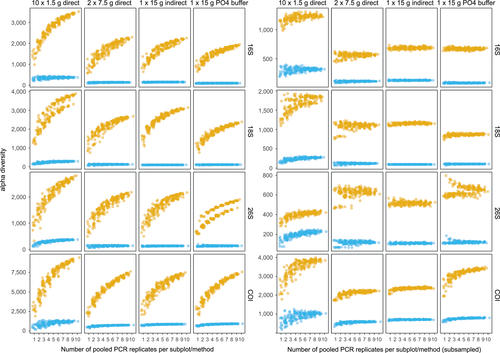

**Figure 6**

Open in figure viewer[PowerPoint](https://besjournals.onlinelibrary.wiley.com/action/downloadFigures?id=mee313086-fig-0006&doi=10.1111%2F2041-210X.13086)

Alpha diversity estimates resulting from pooling combinations of 1–10 PCRs (left) or from subsampling an equal number of sequence reads from pooled combinations of 1–10 PCRs (right) for 16S, 18S, 26S, and cytochrome *c* oxidase subunit I (COI) amplicons from four DNA extraction methods applied to 15 g soil subsamples from subplot D. Gold and blue points represent estimated species richness and effective alpha diversity (calculated as the exponential of Shannon entropy; Jost, 2006) respectively

## 4 DISCUSSION

Our results show that sample size in combination with DNA extraction method and the number of PCRs have important effects on biodiversity estimates for different taxonomic groups within soil. The alpha diversity estimates observed for different methods and taxonomic groups confirm that extraction of DNA from larger amounts of soil tends to result in higher estimates of metazoan biodiversity (Taberlet et al., 2012). Although the highest metazoan gamma diversity estimates tended to result from sets of ten 1.5 g direct extractions, the higher estimates of arthropod alpha diversity in individual PCRs from 7.5 g direct and 15 g phosphate buffer extractions suggest that 10 separate extractions using either of the latter methods would result in more comprehensive samples of metazoan biodiversity than the former. Larger samples also resulted in the most discrimination of within- and between-subplot distances for eukaryotes (especially metazoans), whereas overlapping distances based on 1.5 g soil DNA extracts suggested that this is not ideal for comparing metazoan communities among habitats. Of course, this may be due to each set of 1.5 g direct extracts and PCRs representing 10 small subsamples of soil, whereas the results from the larger extraction methods represent replicate PCRs from one (or two) large samples, resulting in greater heterogeneity among the former than the latter. The 15 g indirect extractions tended to produce lower estimates of metazoan biodiversity than the 15 g phosphate buffer extractions, despite the former method being targeted at microfauna (Velasco-Castrillón et al., 2014). This suggests that the sieving and centrifugation steps involved in this method may have resulted in the exclusion of metazoans that are represented as body fragments or free DNA molecules, rather than whole organisms.

In contrast to the metazoan biodiversity estimates, our results suggest that DNA extraction size is a less important consideration for analyses of prokaryote or microeukaryote biodiversity. Indeed, the smallest DNA extraction sizes resulted in the highest biodiversity estimates for prokaryotes and some microeukaryote groups, whereas for other microeukaryote phyla there was little difference among the methods. This is consistent with previous studies, which have shown that soil volumes <0.5 g can provide representative samples of bacterial communities (Kang & Mills, 2006; Ranjard et al., 2003), whereas volumes ≥1 g are necessary for representative sampling of fungal communities (Ranjard et al., 2003).

These results are consistent with the suggestion by Taberlet et al. (2012) that larger samples (i.e., larger DNA extraction sizes) are necessary to obtain representative biodiversity estimates for metazoans in soil than for micro-organisms. This can be explained by differences in the sizes, abundances, and distributions of micro- and macro-organisms, with metazoans being larger, less abundant, and more sparsely distributed than prokaryotes or microeukaryotes. Of course, larger samples than 15 g can be processed using the indirect and phosphate buffer methods, and the optimal sample size for analysis of metazoans in soil may well lie beyond the range considered in this study.

Although we observed no obvious differences in the taxonomic range of phyla or classes detected by each DNA extraction method, the strikingly consistent patterns of community structure between the results of different DNA extraction methods applied in different subplots suggest that each method results in the detection of a biased assemblage of OTUs. These results show that a consistent DNA extraction methodology should be used if biodiversity is to be compared among samples and ecosystems, otherwise extraction method biases may cause misleading comparisons. Application of all methods together would likely result in detection of the widest range of organisms, as is the case for analyses of soil microbes (Delmont et al., 2011).

Comparisons of OTU abundances between the results of different DNA extraction methods suggested that many more OTUs were significantly more abundant in the results of 1.5 g direct extractions compared to each other method than vice versa, for all amplicons. OTU abundances are influenced by PCR amplification efficiency, which is in turn affected by factors including inhibitory molecules (Miller, Bryant, Madsen, & Ghiorse, 1999) and template complexity (Fonseca et al., 2012), which are likely to vary among different extraction methods. In this case, most of the 1.5 g direct DNA extracts initially failed to amplify, but were subjected to an additional inhibitor removal step that resulted in greatly improved PCR outcomes. The 1.5 g direct DNA extraction method may also have resulted in less diverse pools of DNA template molecules than the other methods, due to the sample volume. Together, these factors may have caused improved amplification of template molecules from the 1.5 g direct extractions, resulting in higher OTU abundances compared to the other methods.

The barcode identification of individual amplicon pools enabled examination of amplification consistency among sets of PCRs. The overall multivariate similarity of PCRs from the same DNA extract is reassuring, suggesting consistent amplification of molecules in each case. The consistency of the most abundant OTUs within each set of PCRs is particularly striking, showing that certain templates within each extract are always amplified to high abundance, even when the overall efficiency of PCR amplification differs (see Amend, Seifert, & Bruns, 2010; Egge et al., 2013; Elbrecht & Leese, 2015; Porazinska et al., 2009). However, there was increasing variability in less abundant OTUs between PCRs, as demonstrated by an inverse relationship between the total number of OTUs, and their abundance and occurrence among PCRs. This can be partly attributed to the complex composition of soil DNA extracts, with molecules derived from numerous organisms with varying sizes, abundances, and gene copy numbers. These complex templates are amplified with variable efficiency by PCR, due to factors including primer/template mismatches, variation in template AT/GC content, polymerase characteristics, and PCR cycling conditions (Acinas et al., 2005; Elbrecht & Leese, 2015; Polz & Cavanaugh, 1998). Low-abundance OTUs may also result from PCR or sequencing errors (Leray & Knowlton, 2017), or oversplitting of OTUs (Clare, Chain, Littlefair, Cristescu, & Deiner, 2016).

How many PCRs are necessary for estimating soil biodiversity? Previously, Ficetola et al. (2015) suggested that at least eight PCR replicates are required to correctly infer the presence of specific organisms with a low detection probability, while Piggott (2016) concluded that two to six PCR replicates were required to confidently detect an endangered freshwater fish. In this case, the species accumulation curves based on combining multiple PCRs showed some evidence of flattening, suggesting that between 10 and 20 PCRs may have resulted in maximal OTU detection. Of course, PCR and sequencing artefacts may have affected these estimates (Leray & Knowlton, 2017). A common strategy to limit these effects is the exclusion of low-abundance sequences or OTUs (Elbrecht & Leese, 2015; Vesty et al., 2017), yet our estimates were derived from OTU clustering with singleton sequences excluded, and further removal of OTUs with abundances <5 resulted in very similar conclusions. A more conservative filtering approach enabled by individually indexed PCRs is to exclude OTUs based on their occurrences in multiple PCRs (Alberdi et al., 2017). In this case, species accumulation curves based on OTUs that occurred in at least two of each set of PCRs plateaued in the range of 7–10, with richness estimates reduced by some 30%.

Our results show that the optimal number of PCRs will depend on the amenability of the intended targets to PCR amplification along with assumptions about OTU filtering, with detection of the most readily amplified organisms assured from a single PCR, but detection of less consistently amplified targets requiring 5–10 (or more) PCRs. The observed richness estimates were strongly affected by the number of PCRs that were included. This clearly shows that balancing the number of PCRs that are carried out for different samples is an important consideration if species richness comparisons are intended, in addition to the use of consistent DNA extraction methods. These results also imply that previous analyses based on triplicate PCRs (and smaller DNA extraction sizes, for example, Drummond et al., 2015) are likely to have underestimated the extent of soil biodiversity.

Our conclusions are based on soil material from a particular forest site, and the extent to which they apply to soils in different ecosystems and locations is unclear. It may be appropriate to optimize DNA extraction and PCR methods on a case-by-case basis in the form of pilot studies. Together with other recently published examinations of sampling, laboratory, and analysis methods (Alberdi et al., 2017; Dickie et al., 2018; Murray et al., 2015), our results provide a guide for future DNA metabarcoding studies of soil biodiversity.

## ACKNOWLEDGEMENTS

Funding for this research was provided by the New Zealand Tertiary Education Commission in the form of Centre of Research Excellence funding for the Allan Wilson Centre for Molecular Ecology and Evolution, and by the University of Auckland in the form of a Doctoral Scholarship received by AD. Sample collection in the Waitakere Ranges Regional Park was carried out under a research permit provided by Auckland Council (WS593). We thank Georgianne Griffiths for assistance with sample collection, New Zealand Genomics Limited (NZGL) for carrying out the Illumina sequencing, and New Zealand eScience Infrastructure (NeSI) for providing high-performance computing resources and support for this research.

## AUTHORS’ CONTRIBUTIONS

A.D., A.J.D., T.R.B., and R.D.N. designed the research; A.D. carried out the sample collection, DNA extractions, PCR amplifications, sequencing library preparation, and led the writing of the manuscript; A.D. and D.X. carried out the bioinformatic processing, OTU identifications, and biodiversity analyses; A.D. wrote the manuscript; All authors contributed to the drafts and gave final approval for publication.

## DATA ACCESSIBILITY

Illumina sequence data are available from the NCBI Sequence Read Archive under accession SRP148718. https://www.ncbi.nlm.nih.gov/sra/SRP148718. Analysis code, metadata, and processed data used in this research are available from Github. https://doi.org/10.5281/zenodo.1403909.

## Citing Literature

[figure not shown]

[Volume10, Issue1](https://besjournals.onlinelibrary.wiley.com/toc/2041210x/2019/10/1)

January 2019

Pages 120-133

### Recommended

  [Molecular Ecology](https://onlinelibrary.wiley.com/journal/1365294x)

[Download PDF](https://besjournals.onlinelibrary.wiley.com/doi/pdf/10.1111/2041-210X.13086)

back